# PML Assignment Final

Klevin D.

May 28, 2016

### Executive Summary

Using devices such as Jawbone Up, Nike FuelBand, and Fitbit it is now possible to collect a large amount of data about personal activity relatively inexpensively.The goal of this project is to use data from accelerometers on the belt, forearm, arm, and dumbell of 6 participants. The participants were asked to perform barbell lifts correctly and incorrectly in 5 different ways. More information is available from the website here: http://groupware.les.inf.puc-rio.br/har (see the section on the Weight Lifting Exercise Dataset).

### Downloading Data And Cleaning

The data is downloaded and loaded to the appropriate variables.

```r
dim(trainset)
```

```
## [1] 19622   160
```

```r
dim(testset)
```

```
## [1]  20 160
```

Prelimnary look at trainset data shows that there are columns that serve only purpose of representing information about the process and thus dont serve as good predictors. Also, there are columns which contain ‘NA’ values. These columns are removed.

```r
dim(train_notpred)
```

```
## [1] 19622   153
```

```r
dim(train_nona)
```

```
## [1] 19622    53
```

### Evaluate Predictor Correlation

The remaining 52 predictors need to checked for high correlation among themselves. The high correlated predictors may cause bias during modelling and so must be removed. The correlation plot shows relationship between predictors. Predictors that have correlation value more than 0.75 are removed.

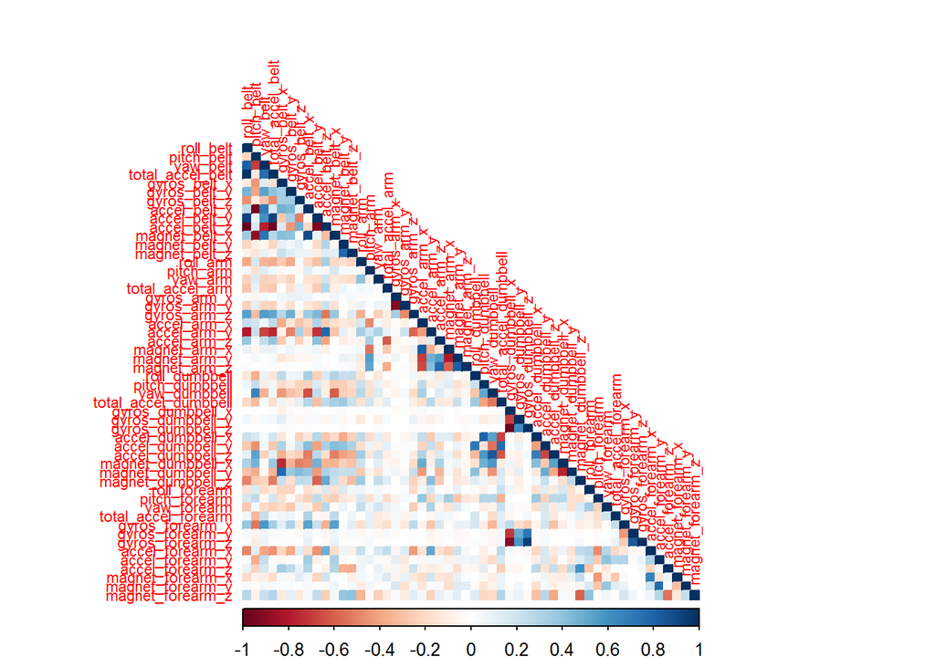

```r
dim(train_lowcor)
```

```
## [1] 19622    32
```

### Split Training Data For Cross Validation

The training dataset with 31 predictors and result columns are split into 2 datasets for training our model and testing it.

```r
dim(mini_train)
```

```
## [1] 13737    32
```

```r
dim(mini_test)
```

```
## [1] 5885   32
```

### Preprocess With Principal Component Analysis

To further reduce the number of variables, the data is preprocessed with principal component method analysis.

```r
dim(mini_train_fin)
```

```
## [1] 13737    23
```

```r
dim(mini_test_fin)
```

```
## [1] 5885   23
```

This dataset with 23 will now be used for model fitting

### Model Fitting

Random forest is used as the training method. Resampling method was selected as cross validation to keep runtimes low while keeping similar level of accuracy.

The model is evaluated on the mini testing dataset.

```
##  Accuracy
## 0.9741716
```

The accuracy of this model is 97.42%, which is very good. This model is accepted and applied to the original test set to classify the observations. Out-of-sample error is 2.58%.

### Testing Prediction

The final test dataset needs to be prepared to match the predictors that are used on the model. The dataset is preprocessed using principal component analysis and then the model is applied. The results are as follows.

```
##  [1] B A A A A E D B A A B C B A E E A B B B
## Levels: A B C D E
```

### Appendix

```r
#download.file("https://d396qusza40orc.cloudfront.net/predmachlearn/pml-training.csv",destfile = "trainingdata.csv")
#download.file("https://d396qusza40orc.cloudfront.net/predmachlearn/pml-testing.csv", destfile = "testingdata.csv")
trainset <- read.csv("trainingdata.csv", header = T, na.strings = c("NA",""))
testset <- read.csv("testingdata.csv", header = T, na.strings = c("NA",""))
```

```r
#remove unrelated variables
train_notpred <- subset(trainset, select = c(8:ncol(trainset)))

#identify columns that have NAs and remove them from train and test sets.
train_nona <- train_notpred[,colSums(is.na(train_notpred))==0]
```

```r
#find correlation between variables other than classe
corrmat <- cor(train_nona[,-53])
library(corrplot)
library(caret)
corrplot(corrmat, type="lower", method="color", tl.cex = 0.7, mar = c(0,2,0,2))

#remove variables that have correlation 0.75 or higher
train_lowcor <- train_nona[,-findCorrelation(corrmat, cutoff = 0.75)]
```

```r
#create dataset from trainset for cross validation
inTrain <- createDataPartition(train_lowcor$classe, p=0.7, list = F)
mini_train <- train_lowcor[inTrain,]
mini_test <- train_lowcor[-inTrain,]
```

```r
#conduct principal component analysis
mini_train_pca <- preProcess(mini_train[,-32], method = "pca")
mini_train_fin <- predict(mini_train_pca, mini_train[,-32])
mini_test_fin  <- predict(mini_train_pca, mini_test[,-32])
```

```r
library(randomForest)
modelFit <- train(mini_train$classe~.,
                  data = mini_train_fin,
                  method="rf",
                  trControl=trainControl(method = "cv", number = 4),
                  allowParallel=T,
                  importance=T)
```

```r
#Check prediction accuracy of model
pred.mini.test <- predict(modelFit, newdata = mini_test_fin)
val_res <- confusionMatrix(pred.mini.test, mini_test$classe)
val_res$overall[1]
```

```r
#Preparing testing data for prediction
library(dplyr)
test_nopca <- cbind(testset[,c(colnames(testset)%in%colnames(train_lowcor))],
                    problem_id=testset$problem_id)

test_fin <- predict(mini_train_pca, test_nopca)

#testing class classification
predict(modelFit, test_fin)
```